# Context

Business communities in the United States are facing high demand for human resources, but one of the constant challenges is identifying and attracting the right talent, which is perhaps the most important element in remaining competitive. Companies in the United States look for hard-working, talented, and qualified individuals both locally as well as abroad.

The Immigration and Nationality Act (INA) of the US permits foreign workers to come to the United States to work on either a temporary or permanent basis. The act also protects US workers against adverse impacts on their wages or working conditions by ensuring US employers' compliance with statutory requirements when they hire foreign workers to fill workforce shortages. The immigration programs are administered by the Office of Foreign Labor Certification (OFLC).

OFLC processes job certification applications for employers seeking to bring foreign workers into the United States and grants certifications in those cases where employers can demonstrate that there are not sufficient US workers available to perform the work at wages that meet or exceed the wage paid for the occupation in the area of intended employment.

# Objective

In FY 2016, the OFLC processed 775,979 employer applications for 1,699,957 positions for temporary and permanent labor certifications. This was a nine percent increase in the overall number of processed applications from the previous year. The process of reviewing every case is becoming a tedious task as the number of applicants is increasing every year.

The increasing number of applicants every year calls for a Machine Learning based solution that can help in shortlisting the candidates having higher chances of VISA approval. OFLC has hired the firm EasyVisa for data-driven solutions. You as a data scientist at EasyVisa have to analyze the data provided and, with the help of a classification model:

- Facilitate the process of visa approvals.
- Recommend a suitable profile for the applicants for whom the visa should be certified or denied based on the drivers that significantly influence the case status.

# Data Description

The data contains the different attributes of the employee and the employer. The detailed data dictionary is given below.

- case_id: ID of each visa application
- continent: Information of continent the employee
- education_of_employee: Information of education of the employee
- has_job_experience: Does the employee has any job experience? Y= Yes; N = No
- requires_job_training: Does the employee require any job training? Y = Yes; N = No
- no_of_employees: Number of employees in the employer's company
- yr_of_estab: Year in which the employer's company was established
- region_of_employment: Information of foreign worker's intended region of employment in the US.
- prevailing_wage: Average wage paid to similarly employed workers in a specific occupation in the area of intended employment. The purpose of the prevailing wage is to ensure that the foreign worker is not underpaid compared to other workers offering the same or similar service in the same area of employment.
- unit_of_wage: Unit of prevailing wage. Values include Hourly, Weekly, Monthly, and Yearly.
- full_time_position: Is the position of work full-time? Y = Full-Time Position; N = Part-Time Position
- case_status: Flag indicating if the Visa was certified or denied

## Import Initial Libraries

```python
import pandas as pd
import numpy as np
from sklearn import metrics
import matplotlib.pyplot as plt
%matplotlib inline
import warnings
warnings.filterwarnings('ignore')
import seaborn as sns
from sklearn.model_selection import train_test_split
from sklearn.model_selection import GridSearchCV
from sklearn import metrics
from sklearn.tree import DecisionTreeClassifier
from sklearn.ensemble import AdaBoostClassifier, GradientBoostingClassifier
#To install xgboost library use - !pip install xgboost
from xgboost import XGBClassifier
from sklearn.ensemble import BaggingClassifier, RandomForestClassifier
from sklearn.linear_model import LogisticRegression
```

# Load and Review the Data

```python
df = pd.read_csv("EasyVisa.csv") #import the data
```

```python
df.head() # To check first 5 rows of data set
```

|  | case_id | continent | education_of_employee | has_job_experience | requires_job_training | no_of_employees | yr_of_estab | region_of_employment | prevailing_wage | unit_of_wage | full_time_position | case_status |
| --- | --- | --- | --- | --- | --- | --- | --- | --- | --- | --- | --- | --- |
| 0 | EZYV01 | Asia | High School | N | N | 14513 | 2007 | West | 592.2029 | Hour | Y | Denied |
| 1 | EZYV02 | Asia | Master's | Y | N | 2412 | 2002 | Northeast | 83425.6500 | Year | Y | Certified |
| 2 | EZYV03 | Asia | Bachelor's | N | Y | 44444 | 2008 | West | 122996.8600 | Year | Y | Denied |
| 3 | EZYV04 | Asia | Bachelor's | N | N | 98 | 1897 | West | 83434.0300 | Year | Y | Denied |
| 4 | EZYV05 | Africa | Master's | Y | N | 1082 | 2005 | South | 149907.3900 | Year | Y | Certified |

```python
df.info() # Identify the data types.
```

```
<class 'pandas.core.frame.DataFrame'>
RangeIndex: 25480 entries, 0 to 25479
Data columns (total 12 columns):
 #   Column                 Non-Null Count  Dtype
---  ------                 --------------  -----
 0   case_id                25480 non-null  object
 1   continent              25480 non-null  object
 2   education_of_employee  25480 non-null  object
 3   has_job_experience     25480 non-null  object
 4   requires_job_training  25480 non-null  object
 5   no_of_employees        25480 non-null  int64
 6   yr_of_estab            25480 non-null  int64
 7   region_of_employment   25480 non-null  object
 8   prevailing_wage        25480 non-null  float64
 9   unit_of_wage           25480 non-null  object
 10  full_time_position     25480 non-null  object
 11  case_status            25480 non-null  object
dtypes: float64(1), int64(2), object(9)
memory usage: 2.3+ MB
```

```python
df.shape # Check number of columns and rows in data frame
```

```
(25480, 12)
```

```python
df.isnull().values.any() # If there are any null values in data set
```

```
False
```

The data does not include any null values.

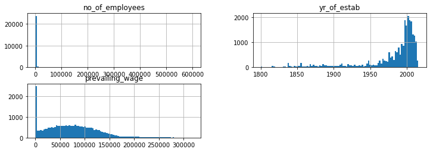

```python
columns = list(df)[0:-1] # Excluding Outcome column which has only
df[columns].hist(stacked=False, bins=100, figsize=(12,30), layout=(14,2));
# Histogram of int and float columns
```

# Identify Duplicates

```python
df.groupby(df.columns.tolist(),as_index=False).size()
```

|  | case_id | continent | education_of_employee | has_job_experience | requires_job_training | no_of_employees | yr_of_estab | region_of_employment | prevailing_wage | unit_of_wage | full_time_position | case_status | size |
| --- | --- | --- | --- | --- | --- | --- | --- | --- | --- | --- | --- | --- | --- |
| 0 | EZYV01 | Asia | High School | N | N | 14513 | 2007 | West | 592.2029 | Hour | Y | Denied | 1 |
| 1 | EZYV02 | Asia | Master's | Y | N | 2412 | 2002 | Northeast | 83425.6500 | Year | Y | Certified | 1 |
| 2 | EZYV03 | Asia | Bachelor's | N | Y | 44444 | 2008 | West | 122996.8600 | Year | Y | Denied | 1 |
| 3 | EZYV04 | Asia | Bachelor's | N | N | 98 | 1897 | West | 83434.0300 | Year | Y | Denied | 1 |
| 4 | EZYV05 | Africa | Master's | Y | N | 1082 | 2005 | South | 149907.3900 | Year | Y | Certified | 1 |
| ... | ... | ... | ... | ... | ... | ... | ... | ... | ... | ... | ... | ... | ... |
| 25475 | EZYV9995 | Asia | High School | Y | N | 489 | 1985 | Midwest | 72802.9800 | Year | Y | Denied | 1 |
| 25476 | EZYV9996 | Asia | Bachelor's | N | N | 2452 | 1946 | Midwest | 666.8553 | Hour | Y | Denied | 1 |
| 25477 | EZYV9997 | Asia | Bachelor's | N | N | 16220 | 1994 | Midwest | 86889.8700 | Year | Y | Certified | 1 |
| 25478 | EZYV9998 | Asia | Bachelor's | Y | N | 1273 | 1923 | Northeast | 46124.7900 | Year | Y | Denied | 1 |
| 25479 | EZYV9999 | North America | High School | N | N | 1711 | 2006 | Northeast | 116.3800 | Hour | Y | Denied | 1 |

25480 rows × 13 columns

The data does not contain duplicates.

# Observations:

```python
df.describe().T # Learn the characteristics of the data.
```

|  | count | mean | std | min | 25% | 50% | 75% | max |
| --- | --- | --- | --- | --- | --- | --- | --- | --- |
| no_of_employees | 25480.0 | 5667.043210 | 22877.928848 | -26.0000 | 1022.00 | 2109.00 | 3504.0000 | 602069.00 |
| yr_of_estab | 25480.0 | 1979.409929 | 42.366929 | 1800.0000 | 1976.00 | 1997.00 | 2005.0000 | 2016.00 |
| prevailing_wage | 25480.0 | 74455.814592 | 52815.942327 | 2.1367 | 34015.48 | 70308.21 | 107735.5125 | 319210.27 |

Looking at object data.

```python
# filtering object type columns
cat_columns = df.describe(include=["object"]).columns
cat_columns
```

```
Index(['case_id', 'continent', 'education_of_employee', 'has_job_experience',
       'requires_job_training', 'region_of_employment', 'unit_of_wage',
       'full_time_position', 'case_status'],
      dtype='object')
```

```python
for i in cat_columns:
    print("Unique values in", i, "are :")
    print(df[i].value_counts())
    print("*" * 50)
```

```
Unique values in case_id are :
EZYV10345    1
EZYV4141     1
EZYV9073     1
EZYV11546    1
EZYV4486     1
            ..
EZYV22829    1
EZYV10147    1
EZYV16455    1
EZYV7630     1
EZYV4729     1
Name: case_id, Length: 25480, dtype: int64
Unique values in continent are :
Asia             16861
Europe            3732
North America     3292
South America      852
Africa             551
Oceania            192
Name: continent, dtype: int64
Unique values in education_of_employee are :
Bachelor's     10234
Master's        9634
High School     3420
Doctorate       2192
Name: education_of_employee, dtype: int64
Unique values in has_job_experience are :
Y    14802
N    10678
Name: has_job_experience, dtype: int64
Unique values in requires_job_training are :
N    22525
Y     2955
Name: requires_job_training, dtype: int64
Unique values in region_of_employment are :
Northeast    7195
South        7017
West         6586
Midwest      4307
Island        375
Name: region_of_employment, dtype: int64
Unique values in unit_of_wage are :
Year     22962
Hour      2157
Week       272
Month       89
Name: unit_of_wage, dtype: int64
Unique values in full_time_position are :
Y    22773
N     2707
Name: full_time_position, dtype: int64
Unique values in case_status are :
Certified    17018
Denied        8462
Name: case_status, dtype: int64
```

- case_id is a unique value assigned to each value.
- continent contains six options with Asia being the most common.
- education_of_employee contains four values with Bachelor's being the most common.
- has_job_experience contains two values and the majority of applicants have job experience.
- requires_job_training contains two values and the majority of applicants do not need training.
- region_of_employment contains five values with the most common being te Northeast.
- unit_of_wage contains four values and the most common is year/annual.
- full_time_position contains two values and the majority of the applicants are for full time roles.
- case_status contains two values with the majority of applicatns being certified.

# Exploratory Data Analysis (EDA)

- EDA is an important part of any project involving data.
- It is important to investigate and understand the data better before building a model with it.

## Univariate Analysis

```python
def histogram_boxplot(data, feature, figsize=(12, 7), kde=False, bins=None):
    """
    Boxplot and histogram combined

    data: dataframe
    feature: dataframe column
    figsize: size of figure (default (12,7))
    kde: whether to show the density curve (default False)
    bins: number of bins for histogram (default None)
    """
    f2, (ax_box2, ax_hist2) = plt.subplots(
        nrows=2,  # Number of rows of the subplot grid= 2
        sharex=True,  # x-axis will be shared among all subplots
        gridspec_kw={"height_ratios": (0.25, 0.75)},
        figsize=figsize,
    )  # creating the 2 subplots
    sns.boxplot(
        data=data, x=feature, ax=ax_box2, showmeans=True, color="violet"
    )  # boxplot will be created and a star will indicate the mean value of the column
    sns.histplot(
        data=data, x=feature, kde=kde, ax=ax_hist2, bins=bins, palette="winter"
    ) if bins else sns.histplot(
        data=data, x=feature, kde=kde, ax=ax_hist2
    )  # For histogram
    ax_hist2.axvline(
        data[feature].mean(), color="green", linestyle="--"
    )  # Add mean to the histogram
    ax_hist2.axvline(
        data[feature].median(), color="black", linestyle="-"
    )  # Add median to the histogram
```

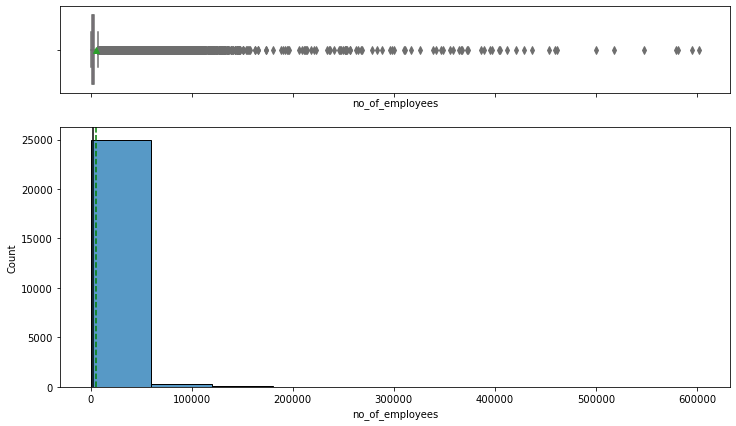

```python
histogram_boxplot(df, "no_of_employees", bins=10)
```

Most companies have less than 100,000 employees. Outliers should be investigated and potentially changed to the median to provide a better representation of the variable's feature importance to predictive models.

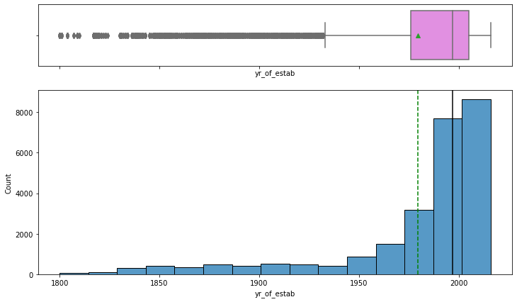

```python
histogram_boxplot(df, "yr_of_estab", bins=15)
```

The majority of companies sponsoring Visa applicants were established after 1975. Unless the Visa application process is unethical, the yr_of_estab variable should not affect an applicant's certification or denial.

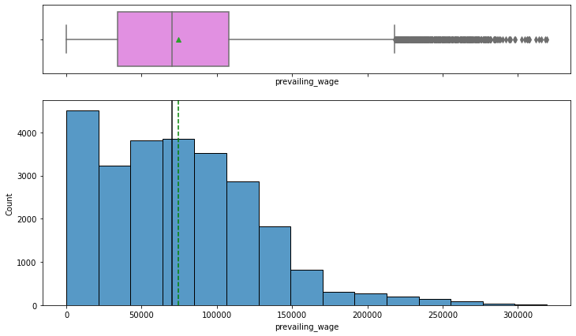

```python
histogram_boxplot(df, "prevailing_wage", bins=15)
```

The prevailing wage data does contain outliers, but the mean and median are close enough to not warrant altering these data sets.

```python
# function to create labeled barplots For percentage Univariate Analysis


def labeled_barplot(data, feature, perc=False, n=None):
    """
    Barplot with percentage at the top

    data: dataframe
    feature: dataframe column
    perc: whether to display percentages instead of count (default is False)
    n: displays the top n category levels (default is None, i.e., display all levels)
    """

    total = len(data[feature])  # length of the column
    count = data[feature].nunique()
    if n is None:
        plt.figure(figsize=(count + 1, 5))
    else:
        plt.figure(figsize=(n + 1, 5))

    plt.xticks(rotation=90, fontsize=15)
    ax = sns.countplot(
        data=data,
        x=feature,
        palette="Paired",
        order=data[feature].value_counts().index[:n].sort_values(),
    )

    for p in ax.patches:
        if perc == True:
            label = "{:.1f}%".format(
                100 * p.get_height() / total
            )  # percentage of each class of the category
        else:
            label = p.get_height()  # count of each level of the category

        x = p.get_x() + p.get_width() / 2  # width of the plot
        y = p.get_height()  # height of the plot

        ax.annotate(
            label,
            (x, y),
            ha="center",
            va="center",
            size=12,
            xytext=(0, 5),
            textcoords="offset points",
        )  # annotate the percentage

    plt.show()  # show the plot
```

## Observations on Continents

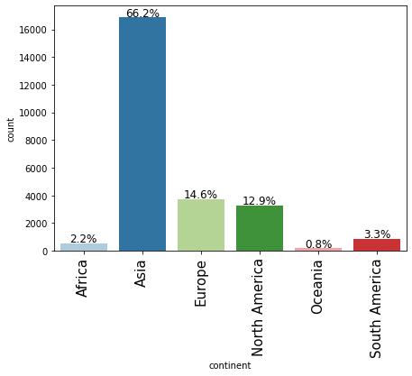

```python
labeled_barplot(df, "continent", perc=True)
```

Asia is the most common home continent for Visa applicants.

## Observations on Education of Employee

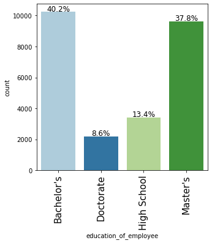

```python
labeled_barplot(df, "education_of_employee", perc=True)
```

The majority of Visa applicants are college educated, with 46% reaching the master's/doctorate level of education.

## Observations on Job Experience

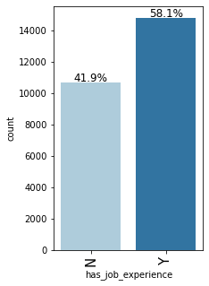

```python
labeled_barplot(df, "has_job_experience", perc=True)
```

The majority of Visa applicants have job experience, but 42% appear to be recent graduates.

## Observations on requiring Job Training

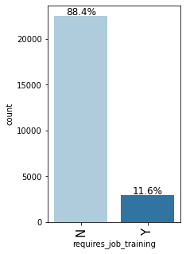

```python
labeled_barplot(df, "requires_job_training", perc=True)
```

Most Visa applicants do not require job training.

## Observations on region of employment

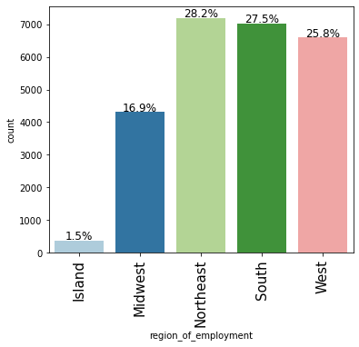

```python
labeled_barplot(df, "region_of_employment", perc=True)
```

The Northeast, South, and West account for over 80% of the visa applicants.

## Observations on unit of wages

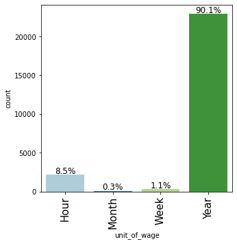

```python
labeled_barplot(df, "unit_of_wage", perc=True)
```

Visa applicants are for annual/yearly wage positions 90% of the time.

## Observations on Full Time vs Part Time

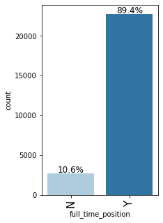

```python
labeled_barplot(df, "full_time_position", perc=True)
```

Visa applicants are for full time positions 90% of the time.

## Observations on Case Status

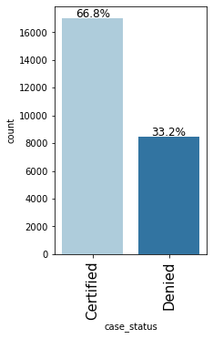

```python
labeled_barplot(df, "case_status", perc=True)
```

Cases are certified two thirds of the time.

## Bivariate Analysis

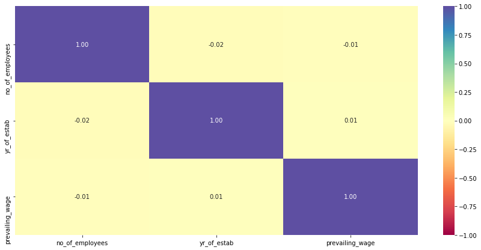

```python
plt.figure(figsize=(15, 7))
sns.heatmap(df.corr(), annot=True, vmin=-1, vmax=1, fmt=".2f", cmap="Spectral")
plt.show()
```

The integer and float data is not correlated.

```python
### Function to plot stacked bar charts for categorical columns
def stacked_plot(x):
    sns.set()
    ## crosstab
    tab1 = pd.crosstab(x, df["case_status"], margins=True).sort_values(
        by="Certified", ascending=False
    )
    print(tab1)
    print("-" * 120)
    ## visualising the cross tab
    tab = pd.crosstab(x, df["case_status"], normalize="index").sort_values(
        by="Certified", ascending=False
    )
    tab.plot(kind="bar", stacked=True, figsize=(17, 7))
    plt.legend(
        loc="lower left", frameon=False,
    )
    plt.legend(loc="upper left", bbox_to_anchor=(1, 1))
    plt.show()
```

```python
def stacked_barplot(data, predictor, target):
    """
    Print the category counts and plot a stacked bar chart

    data: dataframe
    predictor: independent variable
    target: target variable
    """
    count = df[predictor].nunique()
    sorter = df[target].value_counts().index[-1]
    tab1 = pd.crosstab(df[predictor], df[target], margins=True).sort_values(
        by=sorter, ascending=False
    )
    print(tab1)
    print("-" * 120)
    tab = pd.crosstab(df[predictor], df[target], normalize="index").sort_values(
        by=sorter, ascending=False
    )
    tab.plot(kind="bar", stacked=True, figsize=(count + 5, 5))
    plt.legend(
        loc="lower left", frameon=False,
    )
    plt.legend(loc="upper left", bbox_to_anchor=(1, 1))
    plt.show()
```

```
case_status    Certified  Denied    All
continent
All                17018    8462  25480
Asia               11012    5849  16861
North America       2037    1255   3292
Europe              2957     775   3732
South America        493     359    852
Africa               397     154    551
Oceania              122      70    192
------------------------------------------------------------------------------------------------------------------------
```

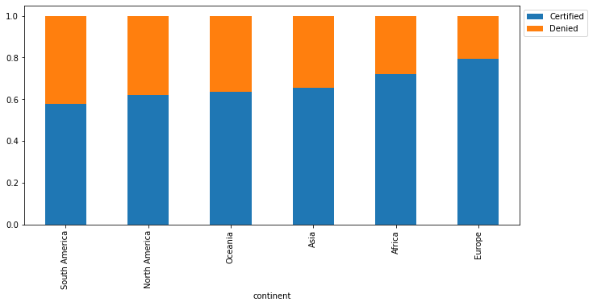

```python
stacked_barplot(df, "continent", "case_status")
```

South American Visa applicants have the lowest certification rate and Europe has the highest.

```
case_status            Certified  Denied    All
education_of_employee
All                        17018    8462  25480
Bachelor's                  6367    3867  10234
High School                 1164    2256   3420
Master's                    7575    2059   9634
Doctorate                   1912     280   2192
------------------------------------------------------------------------------------------------------------------------
```

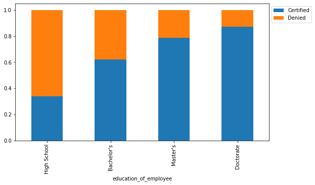

```python
stacked_barplot(df, "education_of_employee", "case_status")
```

The level of education appears to affect the ability to of an applicant to become certified.

```
case_status         Certified  Denied    All
has_job_experience
All                     17018    8462  25480
N                        5994    4684  10678
Y                       11024    3778  14802
------------------------------------------------------------------------------------------------------------------------
```

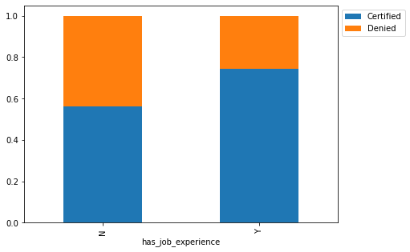

```python
stacked_barplot(df, "has_job_experience", "case_status")
```

Job experience appears to be positively correlated to becoming a certified Visa applicant.

```
case_status            Certified  Denied    All
requires_job_training
All                        17018    8462  25480
N                          15012    7513  22525
Y                           2006     949   2955
------------------------------------------------------------------------------------------------------------------------
```

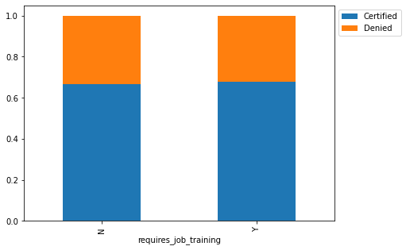

```python
stacked_barplot(df, "requires_job_training", "case_status")
```

Requiring job training does not appear to affect a Visa applicant's success.

```
case_status           Certified  Denied    All
region_of_employment
All                       17018    8462  25480
Northeast                  4526    2669   7195
West                       4100    2486   6586
South                      4913    2104   7017
Midwest                    3253    1054   4307
Island                      226     149    375
------------------------------------------------------------------------------------------------------------------------
```

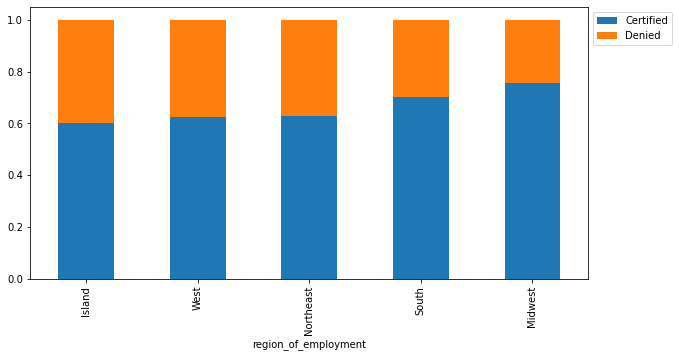

```python
stacked_barplot(df, "region_of_employment", "case_status")
```

A Visa applicant seeking employment in the Midwest appears to lead to the greatest certification rates.

```
case_status   Certified  Denied    All
unit_of_wage
All               17018    8462  25480
Year              16047    6915  22962
Hour                747    1410   2157
Week                169     103    272
Month                55      34     89
------------------------------------------------------------------------------------------------------------------------
```

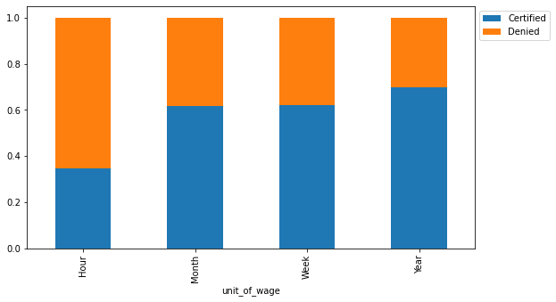

```python
stacked_barplot(df, "unit_of_wage", "case_status")
```

Hourly employees appear to be the least likely to have a Visa application approved.

```
case_status         Certified  Denied    All
full_time_position
All                     17018    8462  25480
Y                       15163    7610  22773
N                        1855     852   2707
------------------------------------------------------------------------------------------------------------------------
```

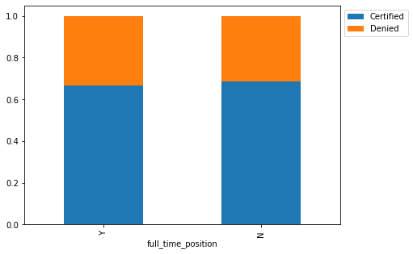

```python
stacked_barplot(df, "full_time_position", "case_status")
```

A job being full time or part time does not appear to correlate to certification or denial.

## Multi-Variate Analysis

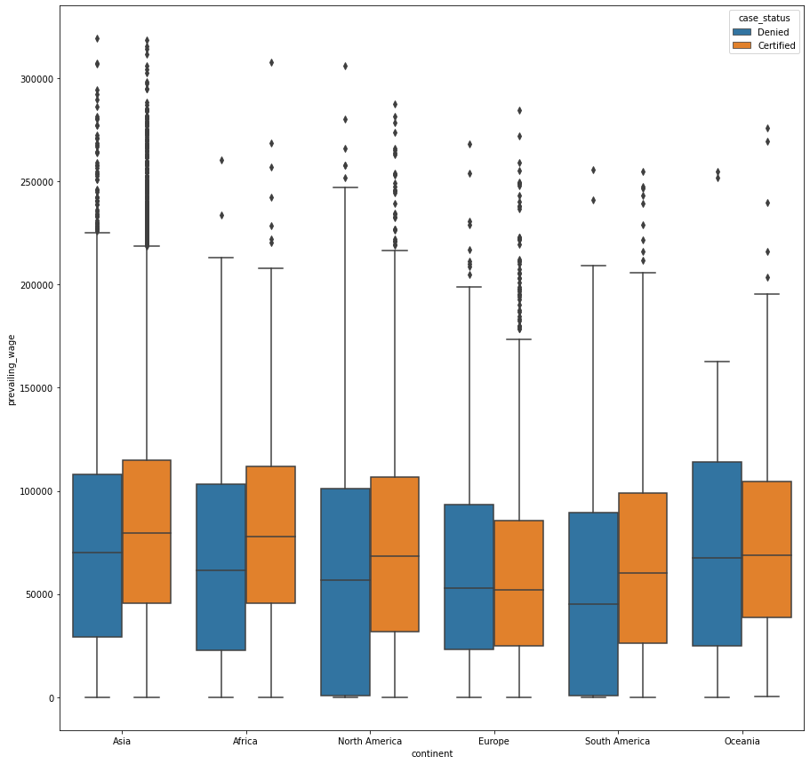

```python
fig, ax = plt.subplots(figsize = (15,15))
a = sns.boxplot(x= "continent", y = 'prevailing_wage' , data = df, hue = 'case_status')
plt.show()
```

Low wages in South and North America appear to be indicators for denying an applicant.

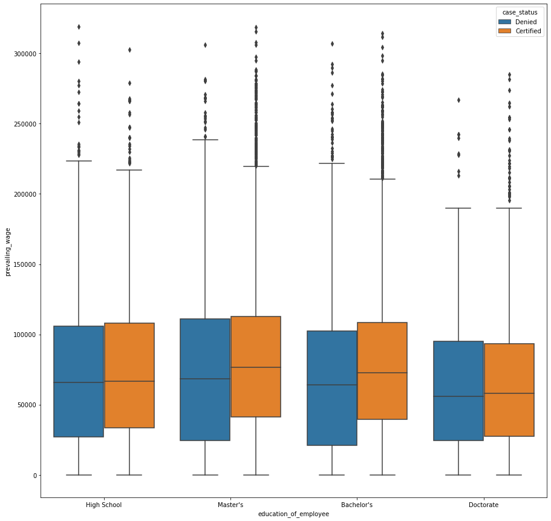

```python
fig, ax = plt.subplots(figsize = (15,15))
a = sns.boxplot(x= "education_of_employee", y = 'prevailing_wage' , data = df, hue = 'case_status')
plt.show()
```

A doctorate surprisingly does not lead to the highest wages.

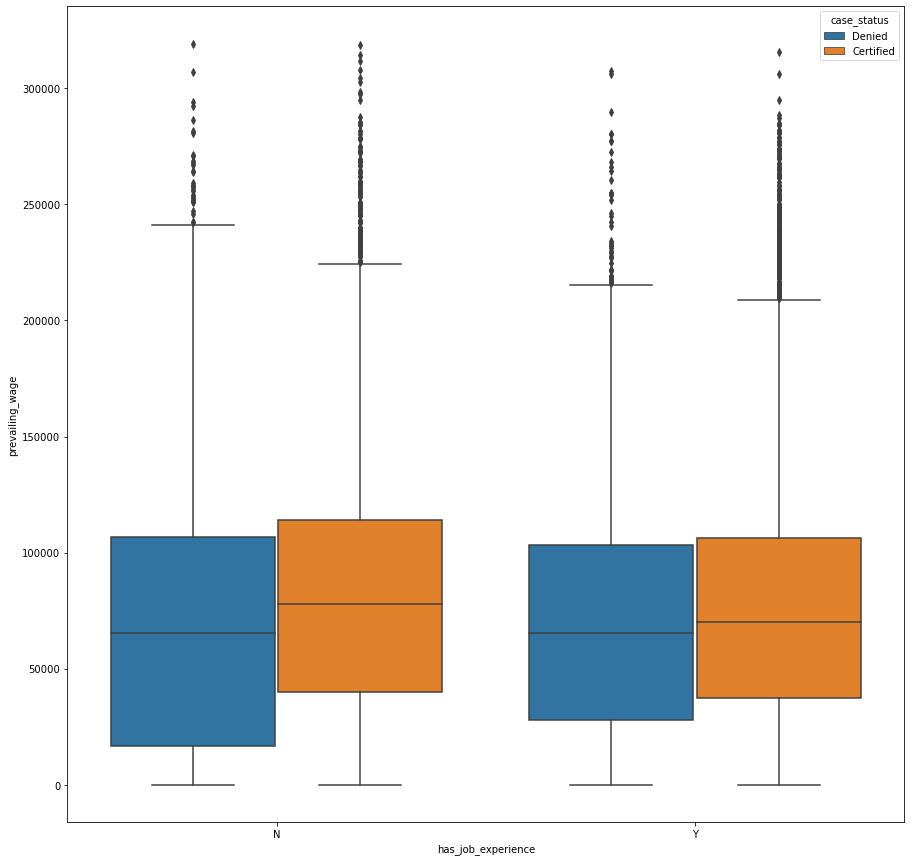

```python
fig, ax = plt.subplots(figsize = (15,15))
a = sns.boxplot(x= "has_job_experience", y = 'prevailing_wage' , data = df, hue = 'case_status')
plt.show()
```

Job experience and prevailing wage appears to be inconclusive for certification/denial rates.

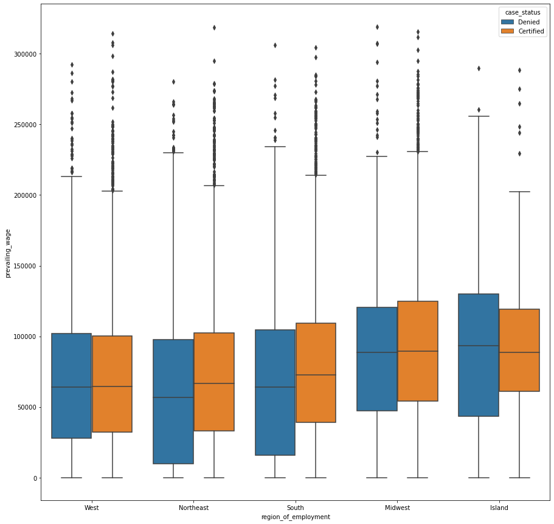

```python
fig, ax = plt.subplots(figsize = (15,15))
a = sns.boxplot(x= "region_of_employment", y = 'prevailing_wage' , data = df, hue = 'case_status')
plt.show()
```

Low wages in the Northeast and South appear to lead to the most denials.

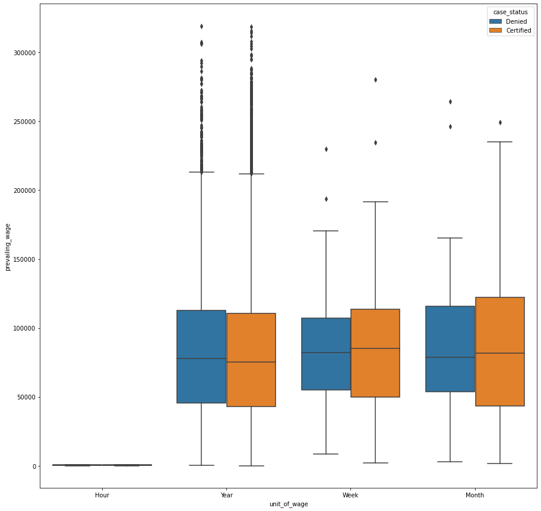

```python
fig, ax = plt.subplots(figsize = (15,15))
a = sns.boxplot(x= "unit_of_wage", y = 'prevailing_wage' , data = df, hue = 'case_status')
plt.show()
```

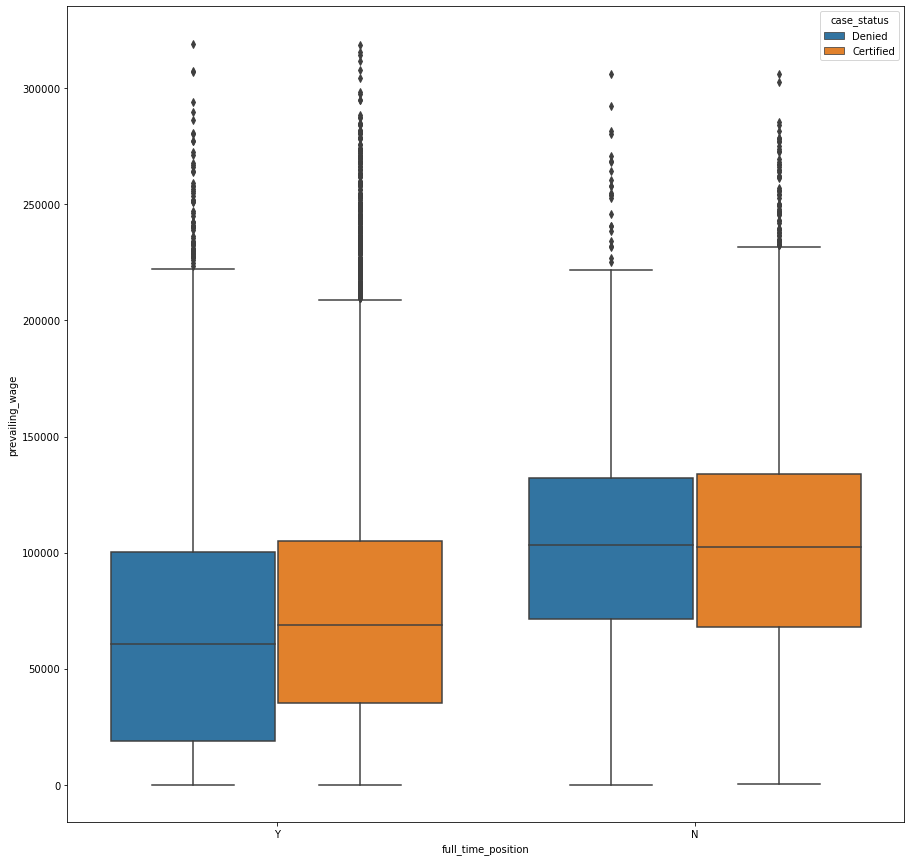

```python
fig, ax = plt.subplots(figsize = (15,15))
a = sns.boxplot(x= "full_time_position", y = 'prevailing_wage' , data = df, hue = 'case_status')
plt.show()
```

Wages for part time positions appear to be higher paying.

# EDA Observations

```python
numerical_columns = [c for c in df.columns if df[c].dtype.name != 'object']

df[df[numerical_columns] < 0].count()
```

```
case_id                   0
continent                 0
education_of_employee     0
has_job_experience        0
requires_job_training     0
no_of_employees          33
yr_of_estab               0
region_of_employment      0
prevailing_wage           0
unit_of_wage              0
full_time_position        0
case_status               0
dtype: int64
```

# Data Preprocessing

## Outlier Identification

```python
quartiles = np.quantile(df['no_of_employees'][df['no_of_employees'].notnull()], [.25, .75])
power_4iqr = 4 * (quartiles[1] - quartiles[0])
print(f'Q1 = {quartiles[0]}, Q3 = {quartiles[1]}, 4*IQR = {power_4iqr}')
outlier_no_of_employees = df.loc[np.abs(df['no_of_employees'] - df['no_of_employees'].median()) > power_4iqr, 'no_of_employees']
outlier_no_of_employees
```

```
Q1 = 1022.0, Q3 = 3504.0, 4*IQR = 9928.0
```

```
0         14513
2         44444
12       123876
14        15756
16        76638
          ...
25441     28199
25443     72892
25455     24335
25464     48785
25471     40224
Name: no_of_employees, Length: 1351, dtype: int64
```

```python
quartiles = np.quantile(df['prevailing_wage'][df['prevailing_wage'].notnull()], [.25, .75])
power_4iqr = 4 * (quartiles[1] - quartiles[0])
print(f'Q1 = {quartiles[0]}, Q3 = {quartiles[1]}, 4*IQR = {power_4iqr}')
outlier_prevailing_wage = df.loc[np.abs(df['prevailing_wage'] - df['prevailing_wage'].median()) > power_4iqr, 'prevailing_wage']
outlier_prevailing_wage
```

```
Q1 = 34015.479999999996, Q3 = 107735.51250000001, 4*IQR = 294880.13000000006
```

```
Series([], Name: prevailing_wage, dtype: float64)
```

```python
quartiles = np.quantile(df['yr_of_estab'][df['yr_of_estab'].notnull()], [.25, .75])
power_4iqr = 4 * (quartiles[1] - quartiles[0])
print(f'Q1 = {quartiles[0]}, Q3 = {quartiles[1]}, 4*IQR = {power_4iqr}')
outlier_yr_of_estab = df.loc[np.abs(df['yr_of_estab'] - df['yr_of_estab'].median()) > power_4iqr, 'yr_of_estab']
outlier_yr_of_estab
```

```
Q1 = 1976.0, Q3 = 2005.0, 4*IQR = 116.0
```

```
31       1880
67       1847
76       1838
111      1864
132      1818
         ...
25418    1838
25423    1848
25437    1876
25444    1838
25463    1838
Name: yr_of_estab, Length: 1501, dtype: int64
```

## Outlier Treatment

The function identified no_of_employees and yr_of_estab as potential variables requiring outlier treatment. These two variables represent employer details that might provide insight into the employer's ability to allocate funds/resources to assisting Visa applicants beyond an external counsel immigration attorney. Additionally, the large amount of identified outliers, 1,351 and 1,501 represent over 5% of the data. Removal of this many outliers could cause any machine learning model to become inaccurate when applying the models to new data despite the added variability these outliers provide. As such, outliers will not be removed from the dataframe.

## Negative Value Identification

```python
df[df.no_of_employees < 0]
```

|  | case_id | continent | education_of_employee | has_job_experience | requires_job_training | no_of_employees | yr_of_estab | region_of_employment | prevailing_wage | unit_of_wage | full_time_position | case_status |
| --- | --- | --- | --- | --- | --- | --- | --- | --- | --- | --- | --- | --- |
| 245 | EZYV246 | Europe | Master's | N | N | -25 | 1980 | Northeast | 39452.9900 | Year | Y | Certified |
| 378 | EZYV379 | Asia | Bachelor's | N | Y | -11 | 2011 | Northeast | 32506.1400 | Year | Y | Denied |
| 832 | EZYV833 | South America | Master's | Y | N | -17 | 2002 | South | 129701.9400 | Year | Y | Certified |
| 2918 | EZYV2919 | Asia | Master's | Y | N | -26 | 2005 | Midwest | 112799.4600 | Year | Y | Certified |
| 6439 | EZYV6440 | Asia | Bachelor's | N | N | -14 | 2013 | South | 103.9700 | Hour | Y | Denied |
| 6634 | EZYV6635 | Asia | Bachelor's | Y | N | -26 | 1923 | West | 5247.3200 | Year | Y | Denied |
| 7224 | EZYV7225 | Europe | Doctorate | N | N | -25 | 1998 | Midwest | 141435.9500 | Year | Y | Certified |
| 7281 | EZYV7282 | Asia | High School | N | N | -14 | 2000 | Midwest | 58488.5000 | Year | Y | Denied |
| 7318 | EZYV7319 | Asia | Bachelor's | Y | Y | -26 | 2006 | South | 115005.6100 | Year | Y | Certified |
| 7761 | EZYV7762 | Asia | Master's | N | N | -11 | 2009 | Midwest | 38457.5100 | Year | Y | Certified |
| 9872 | EZYV9873 | Europe | Master's | Y | N | -26 | 1996 | South | 37397.0500 | Year | Y | Certified |
| 11493 | EZYV11494 | Asia | High School | Y | N | -14 | 1999 | South | 27599.3500 | Year | Y | Denied |
| 13471 | EZYV13472 | North America | Master's | N | N | -17 | 2003 | Northeast | 257.2413 | Hour | Y | Denied |
| 14022 | EZYV14023 | Asia | Bachelor's | N | Y | -11 | 1946 | Northeast | 108403.5600 | Year | Y | Certified |
| 14146 | EZYV14147 | Asia | Bachelor's | N | Y | -26 | 1954 | West | 81982.2700 | Year | Y | Certified |
| 14726 | EZYV14727 | Asia | Master's | N | N | -11 | 2000 | Midwest | 167851.8000 | Year | Y | Certified |
| 15600 | EZYV15601 | Asia | Bachelor's | N | N | -14 | 2014 | South | 24641.6100 | Year | Y | Denied |
| 15859 | EZYV15860 | Asia | High School | N | N | -11 | 1969 | South | 44640.6000 | Year | Y | Denied |
| 16157 | EZYV16158 | Asia | Master's | Y | N | -11 | 1994 | South | 62681.2500 | Year | Y | Certified |
| 16883 | EZYV16884 | North America | Bachelor's | Y | N | -26 | 1968 | Northeast | 168.1558 | Hour | Y | Denied |
| 17006 | EZYV17007 | Asia | Doctorate | Y | N | -11 | 1984 | West | 25753.5100 | Year | Y | Denied |
| 17655 | EZYV17656 | North America | Bachelor's | Y | N | -17 | 2007 | Northeast | 129753.1800 | Year | Y | Denied |
| 17844 | EZYV17845 | Asia | Bachelor's | N | N | -14 | 2012 | West | 29325.8500 | Year | Y | Denied |
| 17983 | EZYV17984 | Asia | Bachelor's | N | N | -26 | 2004 | South | 84359.9800 | Year | Y | Denied |
| 20815 | EZYV20816 | Asia | Bachelor's | N | Y | -17 | 1990 | West | 91897.5700 | Year | Y | Certified |
| 20984 | EZYV20985 | Europe | Doctorate | Y | N | -14 | 1989 | Midwest | 37012.8000 | Year | Y | Certified |
| 21255 | EZYV21256 | North America | High School | N | N | -25 | 1987 | South | 99405.4700 | Year | N | Denied |
| 21760 | EZYV21761 | Asia | Bachelor's | Y | N | -25 | 2000 | West | 100463.5800 | Year | Y | Certified |
| 21944 | EZYV21945 | Africa | Master's | Y | N | -25 | 1977 | Midwest | 79150.5100 | Year | Y | Certified |
| 22084 | EZYV22085 | North America | Bachelor's | Y | N | -14 | 1980 | West | 691.0609 | Hour | Y | Denied |
| 22388 | EZYV22389 | Asia | Master's | Y | N | -14 | 1986 | South | 17893.1100 | Year | Y | Certified |
| 23186 | EZYV23187 | Asia | Master's | N | Y | -11 | 2007 | Midwest | 120195.3500 | Year | Y | Certified |
| 23476 | EZYV23477 | Europe | Master's | Y | N | -11 | 2000 | West | 95072.7500 | Year | Y | Denied |

Negative Values appear to be miskeys. We can correct the miskeys by using an absolute value function for the no_of_employees variable.

```python
df['no_of_employees'] = df['no_of_employees'].abs()
```

```python
df[df.no_of_employees < 0]
```

|  | case_id | continent | education_of_employee | has_job_experience | requires_job_training | no_of_employees | yr_of_estab | region_of_employment | prevailing_wage | unit_of_wage | full_time_position | case_status |
| --- | --- | --- | --- | --- | --- | --- | --- | --- | --- | --- | --- | --- |

```python
df[df[numerical_columns] < 0].count()
```

```
case_id                  0
continent                0
education_of_employee    0
has_job_experience       0
requires_job_training    0
no_of_employees          0
yr_of_estab              0
region_of_employment     0
prevailing_wage          0
unit_of_wage             0
full_time_position       0
case_status              0
dtype: int64
```

The dataframe no longer contains negative values where we would expect positive values.

## Preparing the data for modeling

```python
scale_mapper = {"Certified":0, "Denied":1}
df["case_status"] = df["case_status"].replace(scale_mapper)

df.head()
```

|  | case_id | continent | education_of_employee | has_job_experience | requires_job_training | no_of_employees | yr_of_estab | region_of_employment | prevailing_wage | unit_of_wage | full_time_position | case_status |
| --- | --- | --- | --- | --- | --- | --- | --- | --- | --- | --- | --- | --- |
| 0 | EZYV01 | Asia | High School | N | N | 14513 | 2007 | West | 592.2029 | Hour | Y | 1 |
| 1 | EZYV02 | Asia | Master's | Y | N | 2412 | 2002 | Northeast | 83425.6500 | Year | Y | 0 |
| 2 | EZYV03 | Asia | Bachelor's | N | Y | 44444 | 2008 | West | 122996.8600 | Year | Y | 1 |
| 3 | EZYV04 | Asia | Bachelor's | N | N | 98 | 1897 | West | 83434.0300 | Year | Y | 1 |
| 4 | EZYV05 | Africa | Master's | Y | N | 1082 | 2005 | South | 149907.3900 | Year | Y | 0 |

Certified case statuses are assigned a 0 and Denied case statuses are assigned a 1.

# Model Building - Bagging

```python
#importing additional libraries
from sklearn import tree
from sklearn import metrics
from sklearn.metrics import confusion_matrix, classification_report, accuracy_score, precision_score, recall_score,f1_score,roc_auc_score
```

```python
# copying data to another varaible to avoid any changes to preprocessed data
df1=df.copy()
```

```python
# View the first and last 5 rows of the copied dataset.
df1.head()
```

|  | case_id | continent | education_of_employee | has_job_experience | requires_job_training | no_of_employees | yr_of_estab | region_of_employment | prevailing_wage | unit_of_wage | full_time_position | case_status |
| --- | --- | --- | --- | --- | --- | --- | --- | --- | --- | --- | --- | --- |
| 0 | EZYV01 | Asia | High School | N | N | 14513 | 2007 | West | 592.2029 | Hour | Y | 1 |
| 1 | EZYV02 | Asia | Master's | Y | N | 2412 | 2002 | Northeast | 83425.6500 | Year | Y | 0 |
| 2 | EZYV03 | Asia | Bachelor's | N | Y | 44444 | 2008 | West | 122996.8600 | Year | Y | 1 |
| 3 | EZYV04 | Asia | Bachelor's | N | N | 98 | 1897 | West | 83434.0300 | Year | Y | 1 |
| 4 | EZYV05 | Africa | Master's | Y | N | 1082 | 2005 | South | 149907.3900 | Year | Y | 0 |

```python
df1.tail()
```

|  | case_id | continent | education_of_employee | has_job_experience | requires_job_training | no_of_employees | yr_of_estab | region_of_employment | prevailing_wage | unit_of_wage | full_time_position | case_status |
| --- | --- | --- | --- | --- | --- | --- | --- | --- | --- | --- | --- | --- |
| 25475 | EZYV25476 | Asia | Bachelor's | Y | Y | 2601 | 2008 | South | 77092.57 | Year | Y | 0 |
| 25476 | EZYV25477 | Asia | High School | Y | N | 3274 | 2006 | Northeast | 279174.79 | Year | Y | 0 |
| 25477 | EZYV25478 | Asia | Master's | Y | N | 1121 | 1910 | South | 146298.85 | Year | N | 0 |
| 25478 | EZYV25479 | Asia | Master's | Y | Y | 1918 | 1887 | West | 86154.77 | Year | Y | 0 |
| 25479 | EZYV25480 | Asia | Bachelor's | Y | N | 3195 | 1960 | Midwest | 70876.91 | Year | Y | 0 |

```python
X = df1.drop(["case_status"], axis=1)
Y = df1["case_status"]

X = pd.get_dummies(X, drop_first=True)
```

```python
# Splitting data into training and test set:
X_train, X_test, y_train, y_test = train_test_split(X, Y, test_size=0.3, random_state=1,stratify=Y)
print(X_train.shape, X_test.shape)
```

```
(17836, 25500) (7644, 25500)
```

```python
Y.value_counts(1)
```

```
0    0.667896
1    0.332104
Name: case_status, dtype: float64
```

# Model Evaluation Criterion

## The model can make wrong predictions as:

```python
# defining a function to compute different metrics to check performance of a classification model built using sklearn
def model_performance_classification_sklearn(model, predictors, target):
    """
    Function to compute different metrics to check classification model performance

    model: classifier
    predictors: independent variables
    target: dependent variable
    """

    # predicting using the independent variables
    pred = model.predict(predictors)

    acc = accuracy_score(target, pred)  # to compute Accuracy
    recall = recall_score(target, pred)  # to compute Recall
    precision = precision_score(target, pred)  # to compute Precision
    f1 = f1_score(target, pred)  # to compute F1-score

    # creating a dataframe of metrics
    df_perf = pd.DataFrame(
        {
            "Accuracy": acc,
            "Recall": recall,
            "Precision": precision,
            "F1": f1,
        },
        index=[0],
    )

    return df_perf
```

```python
def confusion_matrix_sklearn(model, predictors, target):
    """
    To plot the confusion_matrix with percentages

    model: classifier
    predictors: independent variables
    target: dependent variable
    """
    y_pred = model.predict(predictors)
    cm = confusion_matrix(target, y_pred)
    labels = np.asarray(
        [
            ["{0:0.0f}".format(item) + "\n{0:.2%}".format(item / cm.flatten().sum())]
            for item in cm.flatten()
        ]
    ).reshape(2, 2)

    plt.figure(figsize=(6, 4))
    sns.heatmap(cm, annot=labels, fmt="")
    plt.ylabel("True label")
    plt.xlabel("Predicted label")
```

# Decision Tree

```
Training performance:
    Accuracy  Recall  Precision   F1
0       1.0     1.0        1.0  1.0
Testing performance:
    Accuracy   Recall  Precision        F1
0  0.698849  0.49232   0.552364  0.520616
```

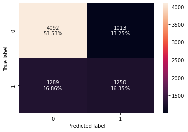

```python
#Fitting the model
d_tree = DecisionTreeClassifier(random_state=1)
d_tree.fit(X_train,y_train)

#Calculating different metrics
dtree_model_train_perf=model_performance_classification_sklearn(d_tree,X_train,y_train)
print("Training performance:\n",dtree_model_train_perf)
dtree_model_test_perf=model_performance_classification_sklearn(d_tree,X_test,y_test)
print("Testing performance:\n",dtree_model_test_perf)
#Creating confusion matrix
confusion_matrix_sklearn(d_tree, X_test, y_test)
```

- The decision tree is overfitting the training data as there is a huge difference between training and test scores for all the metrics.
- The test precision is very low i.e. only 55%

## Random Forest

```
Training performance:
    Accuracy  Recall  Precision   F1
0       1.0     1.0        1.0  1.0
Testing performance:
    Accuracy    Recall  Precision        F1
0  0.739927  0.420638   0.673817  0.517944
```

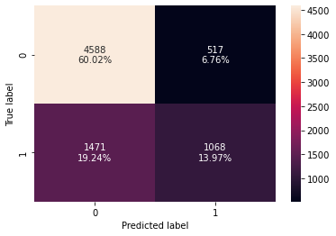

```python
#Fitting the model
rf_estimator = RandomForestClassifier(random_state=1)
rf_estimator.fit(X_train,y_train)

#Calculating different metrics
rf_estimator_model_train_perf=model_performance_classification_sklearn(rf_estimator,X_train,y_train)
print("Training performance:\n",rf_estimator_model_train_perf)
rf_estimator_model_test_perf=model_performance_classification_sklearn(rf_estimator,X_test,y_test)
print("Testing performance:\n",rf_estimator_model_test_perf)

#Creating confusion matrix
confusion_matrix_sklearn(rf_estimator, X_test, y_test)
```

- Random forest is overfitting the training data as there is a large difference between training and test scores for all the metrics.
- The test precision is higher than the decision tree but has a lower test recall.

## Bagging Classifier

```
Training performance:
    Accuracy    Recall  Precision        F1
0  0.965239  0.906635   0.987677  0.945423
Testing performance:
    Accuracy    Recall  Precision        F1
0  0.740581  0.471839   0.651087  0.547157
```

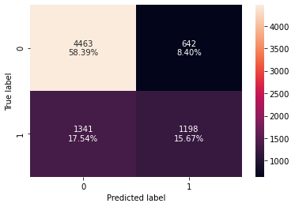

```python
#Fitting the model
bagging_classifier = BaggingClassifier(random_state=1)
bagging_classifier.fit(X_train,y_train)

#Calculating different metrics
bagging_classifier_model_train_perf=model_performance_classification_sklearn(bagging_classifier,X_train,y_train)
print("Training performance:\n",bagging_classifier_model_train_perf)
bagging_classifier_model_test_perf=model_performance_classification_sklearn(bagging_classifier,X_test,y_test)
print("Testing performance:\n",bagging_classifier_model_test_perf)
#Creating confusion matrix
confusion_matrix_sklearn(bagging_classifier, X_test, y_test)
```

## Tuning Decision Tree

```python
#Choose the type of classifier.
dtree_estimator = DecisionTreeClassifier(class_weight={0:0.35,1:0.65},random_state=1)

# Grid of parameters to choose from
parameters = {'max_depth': np.arange(2,10),
              'min_samples_leaf': [5, 7, 10],
              'max_leaf_nodes' : [2, 3, 5, 10],
              'min_impurity_decrease': [0.0001,0.001]
             }

# Type of scoring used to compare parameter combinations
scorer = metrics.make_scorer(metrics.recall_score)

# Run the grid search
grid_obj = GridSearchCV(dtree_estimator, parameters, scoring=scorer,n_jobs=-1)
grid_obj = grid_obj.fit(X_train, y_train)

# Set the clf to the best combination of parameters
dtree_estimator = grid_obj.best_estimator_

# Fit the best algorithm to the data.
dtree_estimator.fit(X_train, y_train)
```

```
DecisionTreeClassifier(class_weight={0: 0.35, 1: 0.65}, max_depth=2,
                       max_leaf_nodes=3, min_impurity_decrease=0.0001,
                       min_samples_leaf=5, random_state=1)
```

```
Training performance:
    Accuracy    Recall  Precision        F1
0  0.638316  0.704542    0.47025  0.564033
Testing performance:
    Accuracy    Recall  Precision        F1
0  0.641418  0.714061   0.473615  0.569499
```

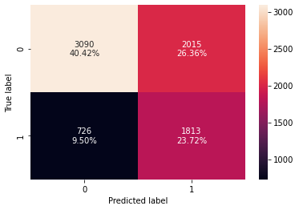

```python
#Calculating different metrics
dtree_estimator_model_train_perf=model_performance_classification_sklearn(dtree_estimator,X_train,y_train)
print("Training performance:\n",dtree_estimator_model_train_perf)
dtree_estimator_model_test_perf=model_performance_classification_sklearn(dtree_estimator,X_test,y_test)
print("Testing performance:\n",dtree_estimator_model_test_perf)
#Creating confusion matrix
confusion_matrix_sklearn(dtree_estimator, X_test, y_test)
```

## Tuning Random Forest

```python
# Choose the type of classifier.
rf_tuned = RandomForestClassifier(class_weight={0:0.35,1:0.65},random_state=1)

parameters = {
                'max_depth': list(np.arange(3,7,1)),
                'max_features': np.arange(0.7,.9,0.1),
                'max_samples': np.arange(0.7,.9,0.1),
                'min_samples_split': np.arange(2, 10, 5),
                'n_estimators': np.arange(30,90,20),
                'min_impurity_decrease': [0.0001,0.001]
}


# Type of scoring used to compare parameter combinations
scorer = metrics.make_scorer(metrics.recall_score)

# Run the grid search
grid_obj = GridSearchCV(rf_tuned, parameters, scoring=scorer,cv=5,n_jobs=-1)
grid_obj = grid_obj.fit(X_train, y_train)

# Set the clf to the best combination of parameters
rf_tuned = grid_obj.best_estimator_

# Fit the best algorithm to the data.
rf_tuned.fit(X_train, y_train)
```

```
RandomForestClassifier(class_weight={0: 0.35, 1: 0.65}, max_depth=3,
                       max_features=0.7999999999999999, max_samples=0.7,
                       min_impurity_decrease=0.0001, n_estimators=30,
                       random_state=1)
```

```
Training performance:
    Accuracy    Recall  Precision        F1
0  0.676441  0.712308   0.509172  0.593849
Testing performance:
    Accuracy    Recall  Precision        F1
0  0.684066  0.727846   0.517357  0.604811
```

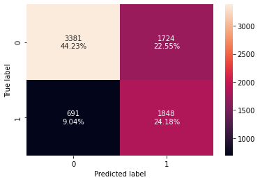

```python
#Calculating different metrics
rf_tuned_model_train_perf=model_performance_classification_sklearn(rf_tuned,X_train,y_train)
print("Training performance:\n",rf_tuned_model_train_perf)
rf_tuned_model_test_perf=model_performance_classification_sklearn(rf_tuned,X_test,y_test)
print("Testing performance:\n",rf_tuned_model_test_perf)

#Creating confusion matrix
confusion_matrix_sklearn(rf_tuned, X_test, y_test)
```

- The test recall has increased significantly after hyperparameter tuning and the random forest is giving generalized performance.
- The confusion matrix shows that the model can barely identify the majority of Visa applicants who should be certified, but the test precision is very low i.e. only 52%.

## Tuning Bagging Classifier

```python
# Choose the type of classifier.
bagging_estimator_tuned = BaggingClassifier(random_state=1)

# Grid of parameters to choose from
parameters = {'max_samples': [0.7,0.8,0.9],
              'max_features': [0.7,0.8,0,9],
              'n_estimators' : [10,20,30],
             }

# Type of scoring used to compare parameter combinations
acc_scorer = metrics.make_scorer(metrics.recall_score)

# Run the grid search
grid_obj = GridSearchCV(bagging_estimator_tuned, parameters, scoring=acc_scorer,cv=5)
grid_obj = grid_obj.fit(X_train, y_train)

# Set the clf to the best combination of parameters
bagging_estimator_tuned = grid_obj.best_estimator_

# Fit the best algorithm to the data.
bagging_estimator_tuned.fit(X_train, y_train)
```

```
BaggingClassifier(max_features=0.8, max_samples=0.7, n_estimators=30,
                  random_state=1)
```

```
Training performance:
    Accuracy    Recall  Precision        F1
0  0.965351  0.904947   0.989843  0.945493
Testing performance:
    Accuracy    Recall  Precision        F1
0   0.74686  0.461599   0.673563  0.547792
```

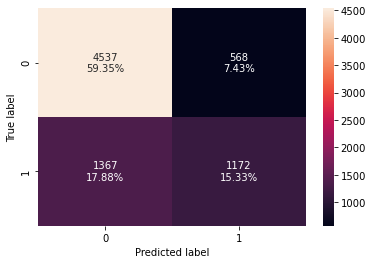

```python
#Calculating different metrics
bagging_estimator_tuned_model_train_perf=model_performance_classification_sklearn(bagging_estimator_tuned,X_train,y_train)
print("Training performance:\n",bagging_estimator_tuned_model_train_perf)
bagging_estimator_tuned_model_test_perf=model_performance_classification_sklearn(bagging_estimator_tuned,X_test,y_test)
print("Testing performance:\n",bagging_estimator_tuned_model_test_perf)

#Creating confusion matrix
confusion_matrix_sklearn(bagging_estimator_tuned, X_test, y_test)
```

- The tuned model is overfitting the training data but the test precision is one of the highest values.
- The confusion matrix shows that the model can identify the majority of Visa applicants who should be certified.

```python
# training performance comparison

models_train_comp_df = pd.concat(
    [dtree_model_train_perf.T,dtree_estimator_model_train_perf.T,rf_estimator_model_train_perf.T,rf_tuned_model_train_perf.T,
     bagging_classifier_model_train_perf.T,bagging_estimator_tuned_model_train_perf.T],
    axis=1,
)
models_train_comp_df.columns = [
    "Decision Tree",
    "Decision Tree Estimator",
    "Random Forest Estimator",
    "Random Forest Tuned",
    "Bagging Classifier",
    "Bagging Estimator Tuned"]
print("Training performance comparison:")
models_train_comp_df
```

```
Training performance comparison:
```

|  | Decision Tree | Decision Tree Estimator | Random Forest Estimator | Random Forest Tuned | Bagging Classifier | Bagging Estimator Tuned |
| --- | --- | --- | --- | --- | --- | --- |
| Accuracy | 1.0 | 0.638316 | 1.0 | 0.676441 | 0.965239 | 0.965351 |
| Recall | 1.0 | 0.704542 | 1.0 | 0.712308 | 0.906635 | 0.904947 |
| Precision | 1.0 | 0.470250 | 1.0 | 0.509172 | 0.987677 | 0.989843 |
| F1 | 1.0 | 0.564033 | 1.0 | 0.593849 | 0.945423 | 0.945493 |

```python
# testing performance comparison

models_test_comp_df = pd.concat(
    [dtree_model_test_perf.T,dtree_estimator_model_test_perf.T,rf_estimator_model_test_perf.T,rf_tuned_model_test_perf.T,
     bagging_classifier_model_test_perf.T, bagging_estimator_tuned_model_test_perf.T],
    axis=1,
)
models_test_comp_df.columns = [
    "Decision Tree",
    "Decision Tree Estimator",
    "Random Forest Estimator",
    "Random Forest Tuned",
    "Bagging Classifier",
    "Bagging Estimator Tuned"]
print("Testing performance comparison:")
models_test_comp_df
```

```
Testing performance comparison:
```

|  | Decision Tree | Decision Tree Estimator | Random Forest Estimator | Random Forest Tuned | Bagging Classifier | Bagging Estimator Tuned |
| --- | --- | --- | --- | --- | --- | --- |
| Accuracy | 0.698849 | 0.641418 | 0.739927 | 0.684066 | 0.740581 | 0.746860 |
| Recall | 0.492320 | 0.714061 | 0.420638 | 0.727846 | 0.471839 | 0.461599 |
| Precision | 0.552364 | 0.473615 | 0.673817 | 0.517357 | 0.651087 | 0.673563 |
| F1 | 0.520616 | 0.569499 | 0.517944 | 0.604811 | 0.547157 | 0.547792 |

# Building the model

- We are going to build 2 ensemble models here - AdaBoost Classifier and Gradient Boosting Classifier.
- First, we'll build these models with default parameters and then use hyperparameter tuning to optimize the model performance.
- We will calculate all three metrics - Accuracy, Precision and Recall but the metric of interest here is precision.
- Precision - It gives the ratio of False positives to Actual positives, so high Precision implies low false positives, i.e. low chances of predicting a denial as a certified.